# Syllabus

Timothy Daley

September 26, 2016

# Classes

- Lectures: Monday, Tuesday, and Wednesday
- Recitation: Thursday
- 11:30 am

# Textbook

The textbook is considered supplemental to classes. We will not cover all topics in the book and we will cover a few topics not in the book.

- http://heather.cs.ucdavis.edu/~matloff/132/PLN/ProbStatBook.pdf

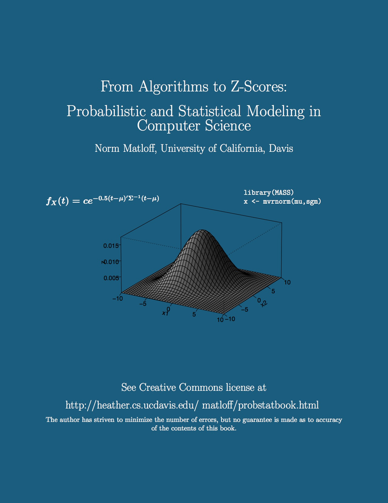

# R

We will be using the statistical programming language R (https://cran.r-project.org/) in this class.

- Advantages:
  - Open source
  - Free
  - Lot’s of available tutorials and packages to help
  - Lot’s of GUI’s (graphical user interfaces available)
  - Works on all systems
- Disadvantages:
  - Non-standard syntax
  - Difficult to optomize

# Rstudio

Rstudio (https://www.rstudio.com/) is an easy to use GUI for R and contains a markdown editor to easily compose pdf or html reports.

I highly suggest using this for homework.

# Homework

- Posted on Canvas on Monday at 5pm.
- Canvas: https://canvas.stanford.edu
- Due the next Friday at 11:59pm through Canvas.
- Late homework will be accepted till the next homework is posted (5pm) for 50 % credit.
- No homework this week.
- Homework makes up a total of 40 % of your final grade.

# Quizes

- Short (~10 minutes) weekly quizes on Thursday at the end of the recitation session.
- Every week except the last week.
- Quizes make up a total of 30 % of your final grade.

# Final Exam

- Friday December 16 at 8:30am
- Room: TBD
- 30% of your final grade

# Office hours

- Tuesday 1-4pm
- Sequoia 105.
- Otherwise by appointment (my office is not in Sequoia)

# Teacher

Timothy Daley (me)

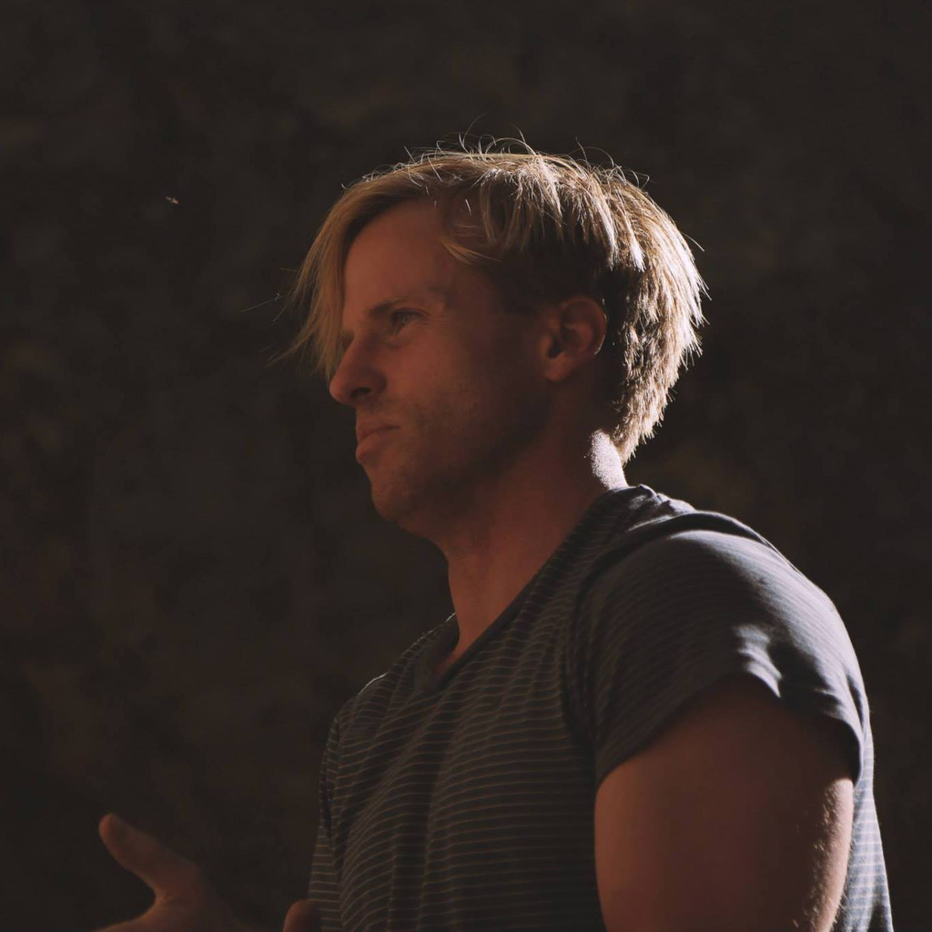

My current specialty is the analysis of large data sets in biological experiments.

# TAs

# Mona Azadkia

mazadkia@stanford.edu

Office hours: Wednesdays 8-10 am

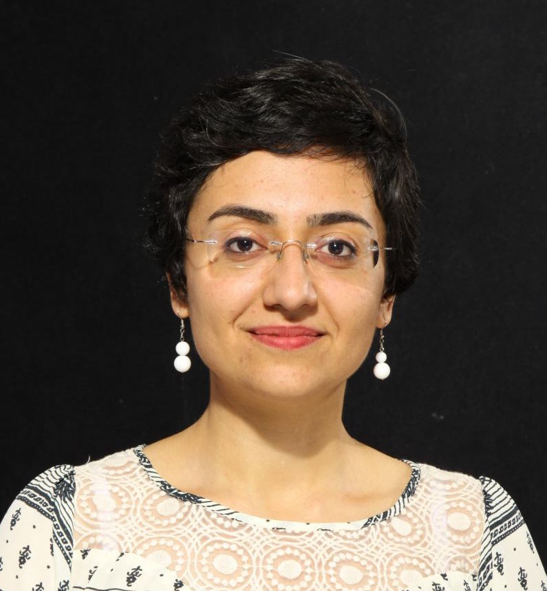

# Claire Donnat

cdonnat@stanford.edu

Office hours: Monday 9-11 am, Sequoia 207

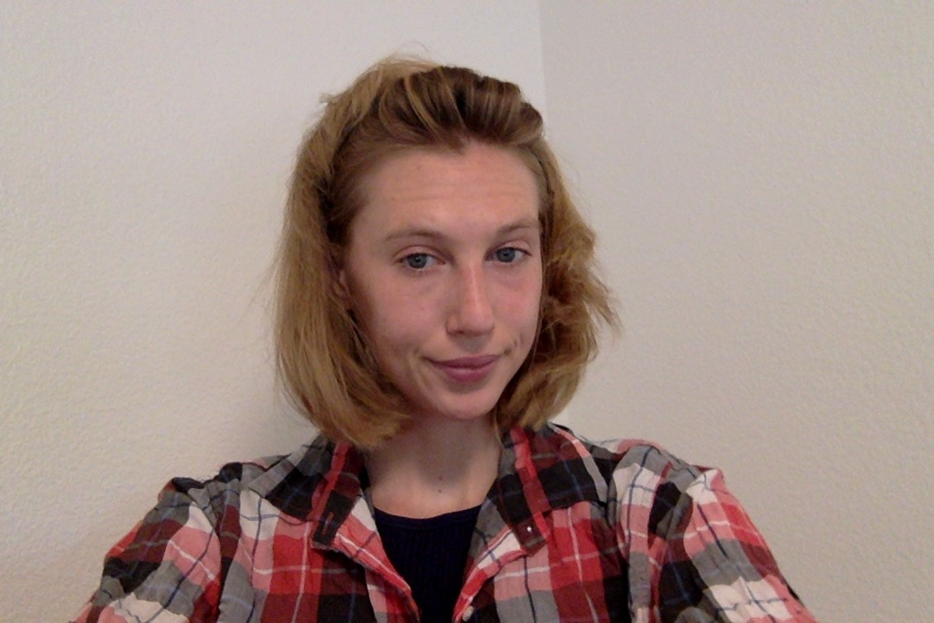

# Snigdha Panigrahi

snigdha@stanford.edu

Office hours: Thursday 2-4 pm.

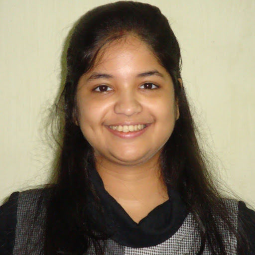

# Slides

- Slides will be posted to Canvas.
- https://canvas.stanford.edu

# Motivation: Understanding the use of statistics

# Motivation

- My objective in this class is to instill an intuition about probability and statistics and how to apply this in real life.
- Example: Should we believe statistical claims backing up news headlines?

[figure not shown]

[figure not shown]

# Real world examples of misuse of statistics

# Sally Clark

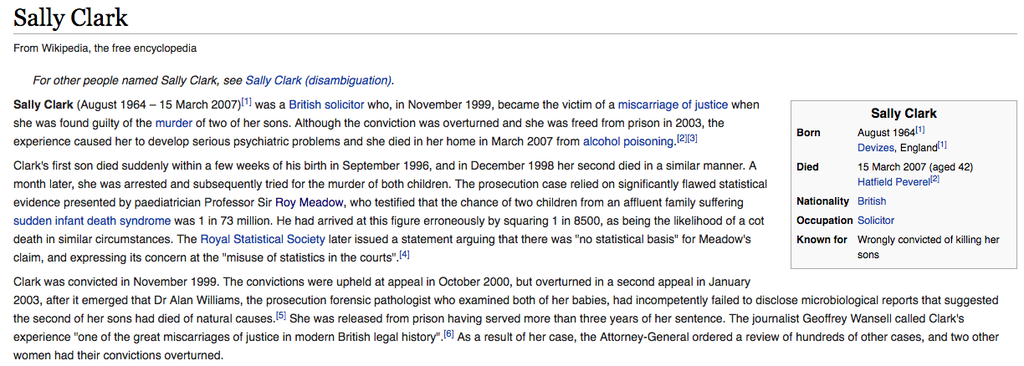

# 1 in 73 million?

Dr. Roy Meadow (pediatrician) testified that “the chance that Sally Clark was innocent was 73,000,000 to 1”

- How did he arrive at this number?
- Chance of cot death = 1/8500
- Chance of 2nd cot death = 1/8500
- The two events don’t effect each other.
- Chance of both = 1/8500*1/8500 $\approx$ 1/73000000
- Therefore: “the chance that Sally Clark was innocent was 73,000,000 to 1”

# Why is this wrong?

- The second cot death may be more likely after the first
  - Underlying genetic factors
  - Underlying environmental factors
- Prosecutor’s fallacy:
  - The probability that the deaths occured by chance is not the probability of innocence.

# Aftermath

- Sally Clark was freed after 3 years.
  - Died of alcohol poisoning 4 years later
- Roy Meadow was found guilty of professional misconduct in 2005 and stripped of his medical license.
  - Reinstated in 2006 on appeal.

# See also

- https://www.ted.com/talks/peter_donnelly_shows_how_stats_fool_juries

# Berkeley graduate school admissions

- In 1973 Berkeley was afraid of being sued for gender discrimination

```r
data("UCBAdmissions")
admitted = apply(UCBAdmissions,c(1,2),sum)
admitted
```

```
##           Gender
## Admit      Male Female
##   Admitted 1198    557
##   Rejected 1493   1278
```

# Overall acceptance rates

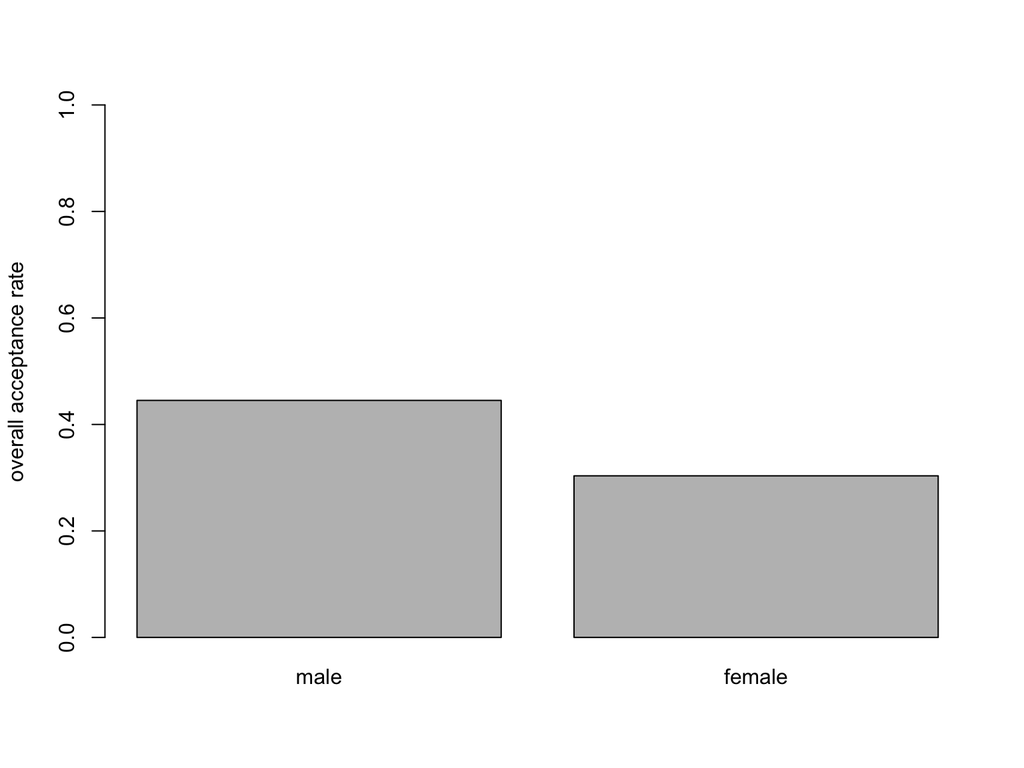

```r
barplot(c(admitted[1,1]/sum(admitted[,1]), admitted[1,2]/sum(admitted[,2])),
        ylim = c(0, 1), width = 0.2, names.arg = c("male", "female"),
        ylab = "overall acceptance rate")
```

# Acceptance rates by department

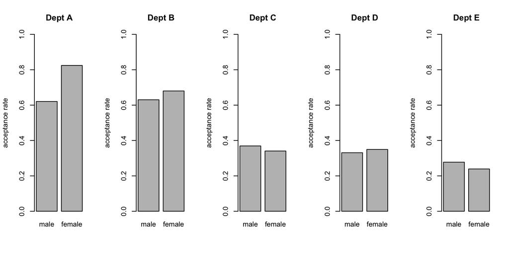

```r
par(mfrow = c(1, 5))
for(dept in c("A", "B", "C", "D", "E")){
  x = UCBAdmissions[ , , dept]
  barplot(c(x[1,1]/sum(x[,1]), x[1,2]/sum(x[,2])),
        ylim = c(0, 1), width = 0.2, names.arg = c("male", "female"),
        ylab = "acceptance rate", main = paste0("Dept ", dept))
}
```

# Acceptance rate vs female application

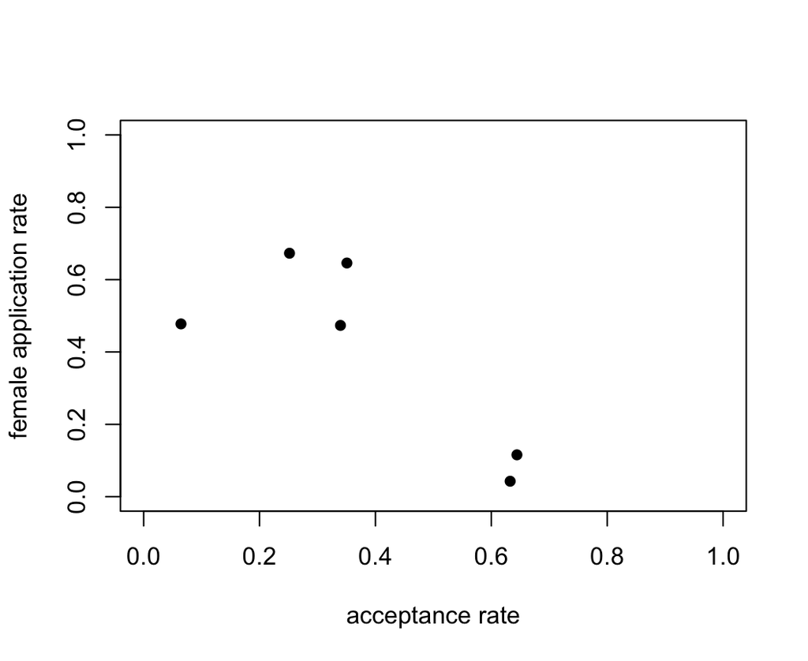

```r
y = c()
for(dept in c("A", "B", "C", "D", "E", "F")){
  x = UCBAdmissions[ , , dept]
  y = rbind(y, c(sum(x[1,])/sum(x), sum(x[,2])/sum(x)))
}
plot(y, pch = 16, xlim = c(0, 1), ylim = c(0, 1),
     xlab = "acceptance rate", ylab = "female application rate")
```

# Confounding factor!

- Decisions of acceptance are made at the department level
- Females tended to apply to more exclusive departments
- Even with no bias in each department, it would appear in aggregate that the school is biased against women.